# Semantic Topics in LLM Reasoning Traces

The corpus is the `thinking` column of the LLM results: one reasoning trace per student profile. `dedupe()` drops blanks, keeps one row per distinct trace, and records each trace’s original frequency in `n`.

```r
traces <- rio::import("For_LLM-results.csv")
corpus <- dedupe(traces$thinking)
nrow(corpus)
```

```
## [1] 95
```

## Four ways to cut a trace, one comparison

A trace runs to a few thousand words, far past what a sentence encoder reads before truncating. `compare_topics()` fits every candidate topic count on four units at once: the whole document, and its sentences, clauses, and phrases. Segments longer than the model’s window are re-split, tiny shards are merged into a neighbour, and numeral-only fragments are dropped. One table, one plot.

```r
comparison <- compare_topics(
  corpus$text,
  n_topics = c(4, 6, 8, 10, 12),
  segment = c("document", "sentence", "clause", "phrase"),
  max_tokens = 200,
  merge_below = 4,
  min_content = 0.5,
  n_representatives = 5,
  cores = 4
)
comparison
```

```
## <sbert_topic_sweep> 20 candidates, coherence measure: npmi
##   segment n_topics coherence topic_diversity explained
##  document        4 0.3346176       0.5000000 0.3958429
##  document        6 0.2838766       0.4666667 0.4547403
##  document        8 0.2449431       0.4125000 0.5340517
##  document       10 0.2367102       0.4600000 0.5545642
##  document       12 0.2390647       0.4166667 0.5817583
##  sentence        4 0.2969108       0.9500000 0.1551577
##  sentence        6 0.3611902       0.8666667 0.2198518
##  sentence        8 0.2810221       0.8375000 0.2459317
##  sentence       10 0.2604619       0.7700000 0.2662687
##  sentence       12 0.2138764       0.7000000 0.3009314
##    clause        4 0.1785650       0.8750000 0.1498494
##    clause        6 0.2153648       0.8666667 0.1967582
##    clause        8 0.1690291       0.8250000 0.2544656
##    clause       10 0.1979487       0.7200000 0.2953643
##    clause       12 0.1936556       0.6916667 0.3207442
##    phrase        4 0.2261228       0.9250000 0.1532400
##    phrase        6 0.2262072       0.8500000 0.1917744
##    phrase        8 0.2099650       0.7875000 0.2462990
##    phrase       10 0.1963079       0.7400000 0.2764159
##    phrase       12 0.1800067       0.6750000 0.2998777
##
## Fitted models retained: fitted(x, n_topics = 6, segment = "sentence")
```

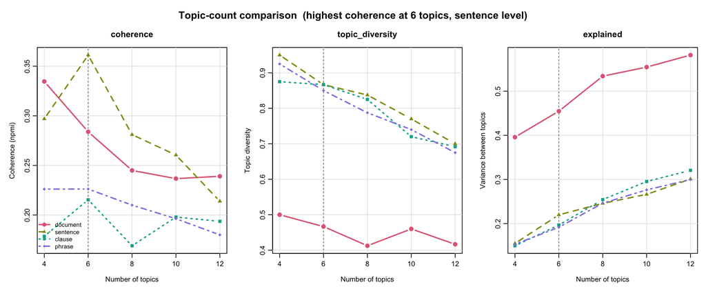

```r
plot(comparison)
```

Read the coherence panel first: it asks whether a topic’s top terms actually co-occur in its units. Diversity asks whether the topics share their vocabulary or own it, and explained variance always rises with more topics, so it is a sanity check rather than a criterion. The document line is the truncated view; the three segment lines model the traces in full.

## The same six topics, four ways

`type = "fit"` on the comparison draws the per-topic report for every level’s six-topic model: count, class-based TF-IDF, and beta term bars beside the units nearest each centroid. One figure per level, same layout, so the segmentations can be read against each other.

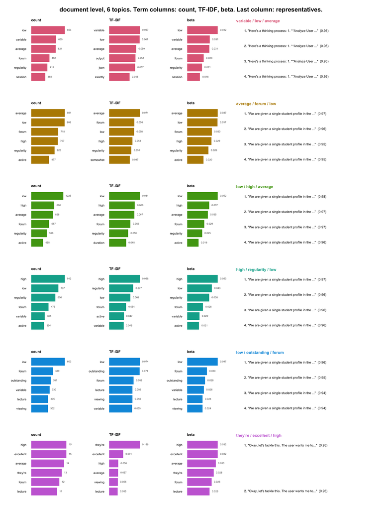

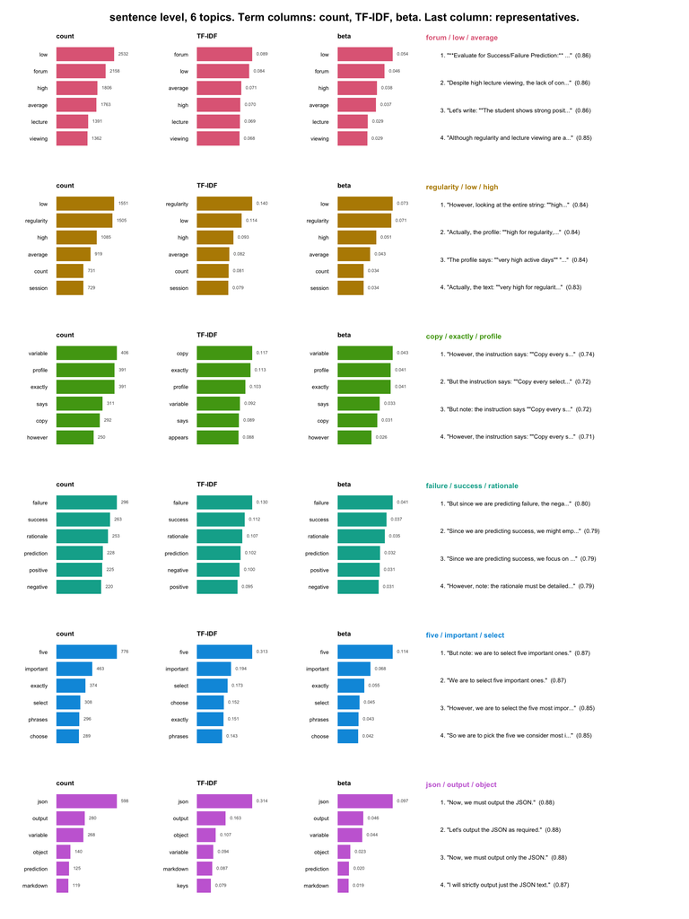

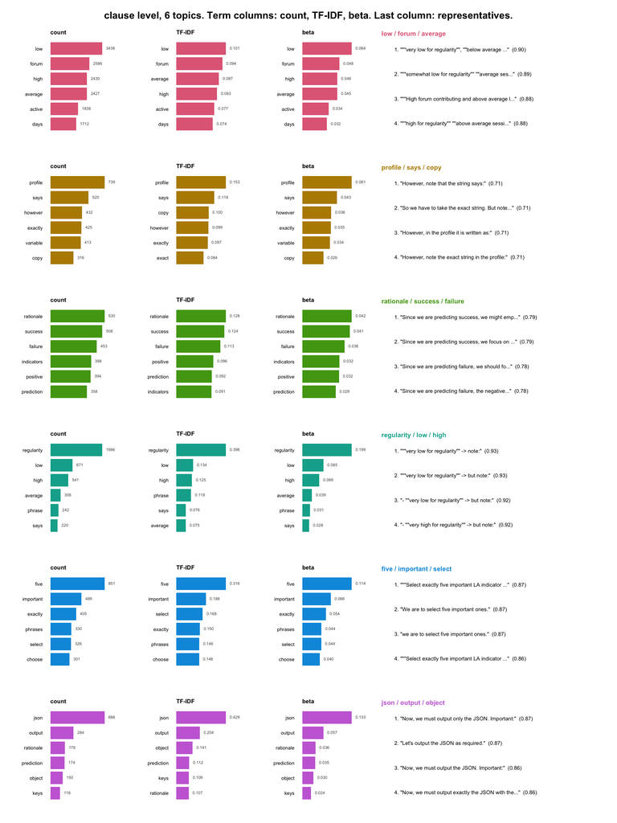

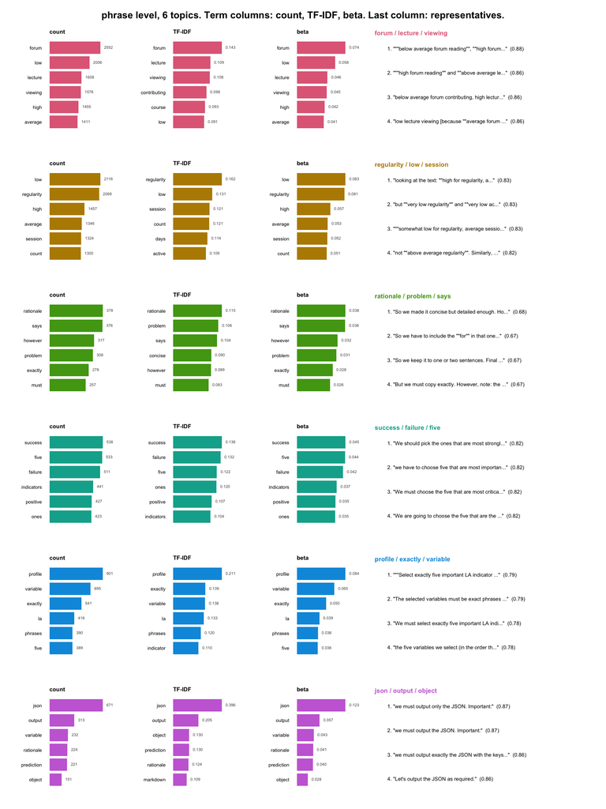

```r
plot(comparison, type = "fit", n_topics = 6, n_terms = 6, n_representatives = 4)
```

## The model

`fitted()` takes the chosen count and level straight out of the comparison, with no refitting.

```r
topic_model <- fitted(comparison, n_topics = 6, segment = "sentence")
topic_model
```

```
## <sbert_topic_model>
##   documents: 95
##   segments: 8422 (sentence level)
##   topics: 6
##   model: sentence-transformers/all-MiniLM-L6-v2
##   algorithm: deterministic k-means (Lloyd)
##   topic sizes: 2495, 1919, 1274, 1130, 1063, 541
##   between/total SS: 22.0%
```

```r
summary(topic_model)
```

```
## Semantic topic model summary
##   documents:            95
##   segments:             8422 (sentence level)
##   topics:               6
##   model:                sentence-transformers/all-MiniLM-L6-v2
##   between/total SS:      22.0%
##   mean npmi  coherence:  0.3612
##   topic topic_diversity:      0.867 (top 10 terms)
##
##  topic                         label n_documents proportion coherence
##      1         forum / low / average        2495    0.29625    0.4374
##      2       regularity / low / high        1919    0.22786    0.4587
##      3      copy / exactly / profile        1274    0.15127    0.4105
##      4 failure / success / rationale        1130    0.13417    0.1564
##      5     five / important / select        1063    0.12622    0.2957
##      6        json / output / object         541    0.06424    0.4084
```

## Size on three scales

Segments per topic, source traces per topic, and traces weighted by how often each was repeated in the raw file. A trace counts in every topic one of its sentences lands in, so document proportions need not sum to one.

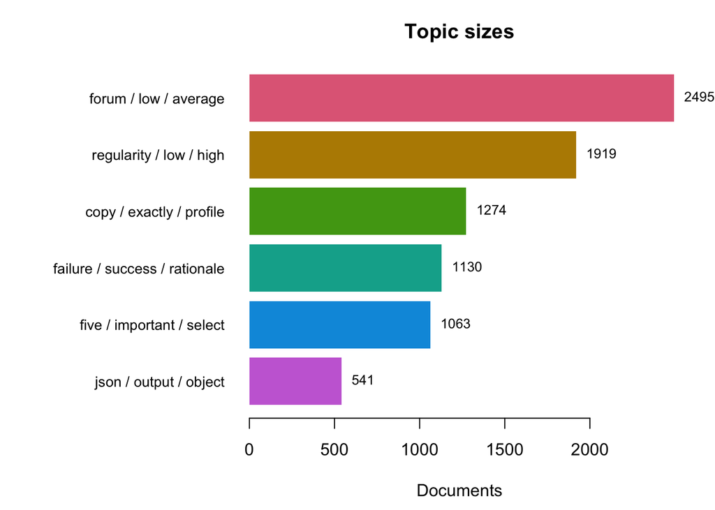

```r
plot(topic_model, type = "sizes")
```

```r
topic_sizes(topic_model, by = "document", weights = corpus$n)
```

```
##   topic                         label n_documents proportion n_weighted
## 1     1         forum / low / average          95  1.0000000         95
## 2     2       regularity / low / high          95  1.0000000         95
## 3     3      copy / exactly / profile          95  1.0000000         95
## 4     4 failure / success / rationale          95  1.0000000         95
## 5     5     five / important / select          91  0.9578947         91
## 6     6        json / output / object          91  0.9578947         91
##   weighted_share
## 1      0.1690391
## 2      0.1690391
## 3      0.1690391
## 4      0.1690391
## 5      0.1619217
## 6      0.1619217
```

Because the model was fitted on sentences, each trace’s mixture over the topics is already stored. `topic_gamma()` returns it with no re-encoding.

```r
head(topic_gamma(topic_model), 12)
```

```
##    document_id topic      gamma n_segments
## 1            1     1 0.35964912        114
## 2            1     2 0.21929825        114
## 3            1     3 0.05263158        114
## 4            1     4 0.16666667        114
## 5            1     5 0.16666667        114
## 6            1     6 0.03508772        114
## 7            2     1 0.40206186         97
## 8            2     2 0.23711340         97
## 9            2     3 0.15463918         97
## 10           2     4 0.05154639         97
## 11           2     5 0.13402062         97
## 12           2     6 0.02061856         97
```

## Two keyword views, one topic

`sort_by = "beta"` orders each topic’s words by how often the topic uses them, the generative view. The default class-based TF-IDF score promotes words this topic uses and the others do not, the discriminative view. A topic is characterised by the pair.

```r
terms(topic_model, n = 8, sort_by = "beta")
```

```
##    topic                         label       term rank      score frequency
## 1      1         forum / low / average        low    1 0.08404310      2532
## 2      1         forum / low / average      forum    2 0.08871849      2158
## 3      1         forum / low / average       high    3 0.06975992      1806
## 4      1         forum / low / average    average    4 0.07130333      1763
## 5      1         forum / low / average    lecture    5 0.06926032      1391
## 6      1         forum / low / average    viewing    6 0.06833710      1362
## 7      1         forum / low / average     course    7 0.06515620      1255
## 8      1         forum / low / average     active    8 0.05584644      1173
## 9      2       regularity / low / high        low    1 0.11392902      1551
## 10     2       regularity / low / high regularity    2 0.14043170      1505
## 11     2       regularity / low / high       high    3 0.09274749      1085
## 12     2       regularity / low / high    average    4 0.08225403       919
## 13     2       regularity / low / high      count    5 0.08067502       731
## 14     2       regularity / low / high    session    6 0.07946253       729
```

[output cut: 83 more lines]

```r
terms(topic_model, n = 5)
```

```
##    topic                         label       term rank      score frequency
## 1      1         forum / low / average      forum    1 0.08871849      2158
## 2      1         forum / low / average        low    2 0.08404310      2532
## 3      1         forum / low / average    average    3 0.07130333      1763
## 4      1         forum / low / average       high    4 0.06975992      1806
## 5      1         forum / low / average    lecture    5 0.06926032      1391
## 6      2       regularity / low / high regularity    1 0.14043170      1505
## 7      2       regularity / low / high        low    2 0.11392902      1551
## 8      2       regularity / low / high       high    3 0.09274749      1085
## 9      2       regularity / low / high    average    4 0.08225403       919
## 10     2       regularity / low / high      count    5 0.08067502       731
## 11     3      copy / exactly / profile       copy    1 0.11734538       292
## 12     3      copy / exactly / profile    exactly    2 0.11349800       391
## 13     3      copy / exactly / profile    profile    3 0.10314333       391
## 14     3      copy / exactly / profile   variable    4 0.09160935       406
```

[output cut: 47 more lines]

## The topics at a glance

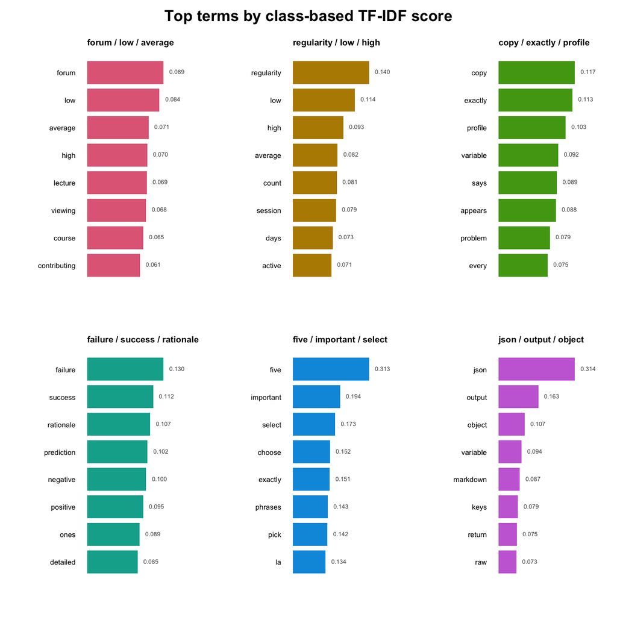

```r
plot(topic_model, type = "terms")
```

The fit report clips its text. `representatives()` ranks the fitted sentences by distinctiveness margin and names the trace and position each one came from.

```r
representatives(topic_model, n = 2)
```

```
##    topic rank document_id segment
## 1      1    1          37     216
## 2      1    2          10      51
## 3      2    1          12      16
## 4      2    2          53      21
## 5      3    1          20      50
## 6      3    2           4      69
## 7      4    1          29      57
## 8      4    2           3      51
## 9      5    1          24      32
## 10     5    2          42      43
## 11     6    1          66      43
## 12     6    2          12      63
##                                                                                                                                                                                           text
## 1                                                                                       "" excellent forum contributing"" But lecture viewing is probably more important than course browsing.
```

[output cut: 24 more lines]

## Where to go from here

`predict()` assigns new traces sentence by sentence with the same segmentation, `topic_membership()` grades each sentence across topics, and `reduce_topics()` merges the six down to fewer while keeping every verb above.